# Modelos jerárquicos

Victor Gallego, Roi Naveiro

26/5/2019

## Instalación de Stan

```r
# Instalando en Windows:
# install.packages("rstan", repos = "https://cloud.r-project.org/", dependencies = TRUE)

# Instalando en Linux:
# sudo add-apt-repository -y "ppa:marutter/rrutter"
# sudo add-apt-repository -y "ppa:marutter/c2d4u"
# sudo apt-get update
# sudo apt-get install r-cran-rstan
# packageurl <- "http://cran.r-project.org/src/contrib/Archive/StanHeaders/StanHeaders_2.17.2.tar.gz"
# install.packages(packageurl, repos=NULL, type="source")
```

## Carga de librerías

```r
library(rstan)
# En función de los avisos, activamos opciones:
options(mc.cores = parallel::detectCores())
rstan_options(auto_write = TRUE)
```

## Modelo de los Ocho Colegios (8 Schools)

Ocho colegios se han sometido a un estudio en que se evaluará el impacto de un tratamiento concreto: coaching a los alumnos.

El modelo es el siguiente

$$\begin{align*}
y_i &\sim \mathcal{N} (\theta_i, \sigma_i),\qquad i=1,...,8 \\
\theta_i &= \mu + \tau \eta_i \\
\eta_i &\sim \mathcal{N} (0, 1)
\end{align*}$$

donde $y_i$ es el efecto estimado del tratamiento en el colegio, $\sigma_i$ el error en desviación estándar de la estimación anterior.

Las variables latentes son $\mu$: efecto global del tratamiento, $\tau$ desviación estándar global del tratamiento, y $\eta_i$ es una desviación local en cada colegio.

1. Completa la parte model del fichero 8schools.stan indicando los parámetros adecuados sobre _

Definimos los datos observados

```r
schools_dat <- list(J = 8,
                    y = c(28,  8, -3,  7, -1,  1, 18, 12),
                    sigma = c(15, 10, 16, 11,  9, 11, 10, 18))
```

2. Ajusta el modelo usando la funcion stan, indicando el fichero .stan y los datos anteriores

```r
# Ajustamos el modelo, primero lo compilará a C y luego hará la inferencia (por defecto)
# con una variante de HMC, NUTS, ya que detecta que el modelo es diferenciable
# Los parámetros del sampler son todos por defecto de momento, pero se pueden especificar como
# argumentos adicionales
fit <- stan(file = '8schools.stan', data = schools_dat)
```

3. Estudia la convergencia del MCMC viendo el estadístico Rhat

```r
print(fit)
```

```
## Inference for Stan model: 8schools.
## 4 chains, each with iter=2000; warmup=1000; thin=1;
## post-warmup draws per chain=1000, total post-warmup draws=4000.
##
##            mean se_mean   sd   2.5%    25%    50%    75%  97.5% n_eff Rhat
## mu         8.28    0.17 5.39  -1.96   4.95   8.11  11.38  20.18  1015    1
## tau        6.56    0.17 5.53   0.27   2.52   5.18   9.01  20.41  1057    1
## eta[1]     0.38    0.01 0.91  -1.47  -0.22   0.39   0.99   2.12  4000    1
## eta[2]    -0.02    0.01 0.88  -1.77  -0.59  -0.03   0.55   1.71  4000    1
## eta[3]    -0.20    0.01 0.91  -1.97  -0.82  -0.20   0.41   1.62  4000    1
## eta[4]    -0.04    0.01 0.90  -1.85  -0.64  -0.04   0.55   1.78  4000    1
## eta[5]    -0.36    0.01 0.89  -2.16  -0.96  -0.37   0.22   1.42  4000    1
## eta[6]    -0.23    0.01 0.91  -1.98  -0.85  -0.25   0.34   1.64  4000    1
## eta[7]     0.33    0.01 0.87  -1.42  -0.24   0.33   0.92   2.03  4000    1
## eta[8]     0.02    0.01 0.93  -1.82  -0.60   0.02   0.66   1.85  4000    1
## theta[1]  11.51    0.18 8.20  -1.90   6.24  10.29  15.42  30.72  2080    1
## theta[2]   8.05    0.10 6.20  -4.55   4.37   7.99  11.61  20.98  4000    1
## theta[3]   6.32    0.13 7.74 -11.89   2.24   6.87  10.93  21.21  3415    1
## theta[4]   7.80    0.10 6.50  -5.40   3.99   7.92  11.70  20.69  4000    1
## theta[5]   5.21    0.10 6.37  -8.81   1.39   5.83   9.41  16.52  4000    1
## theta[6]   6.31    0.10 6.64  -8.27   2.50   6.63  10.61  18.67  4000    1
## theta[7]  10.80    0.11 6.70  -1.00   6.36  10.10  14.47  25.89  4000    1
## theta[8]   8.47    0.14 7.70  -6.60   4.01   8.20  12.67  24.90  3161    1
## lp__     -39.50    0.07 2.57 -45.02 -41.07 -39.30 -37.72 -35.08  1225    1
##
## Samples were drawn using NUTS(diag_e) at Sun May 26 22:40:01 2019.
## For each parameter, n_eff is a crude measure of effective sample size,
## and Rhat is the potential scale reduction factor on split chains (at
## convergence, Rhat=1).
```

4. ¿Qué colegio tiene mayor efecto del tratamiento (en promedio) $\theta_i$ )? ¿Hay alguno para el cual no sea significativo? (esto es, mean($\theta_i$) - sd($\theta_i$) < 0)
5. Obtener las muestras para $\mu$ y representarlas en un histograma

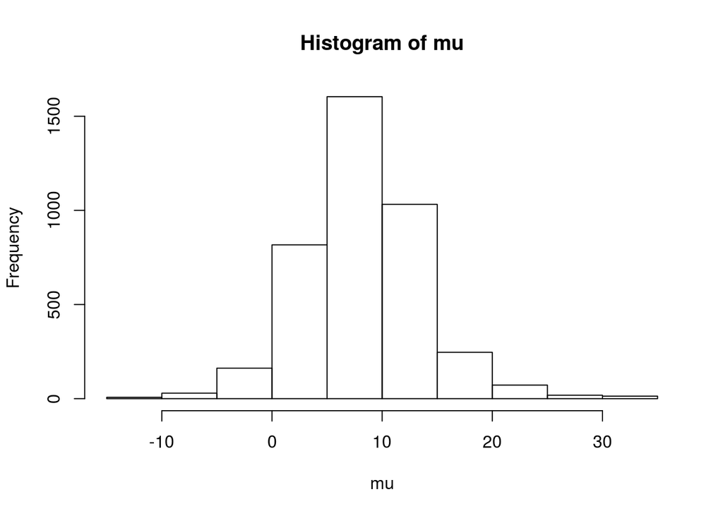

```r
la <- rstan::extract(fit, permuted = TRUE) # para obtener las muestras
mu <- la$mu
hist(mu)
```

6. Calcular la probabilidad a posteriori de que el efecto sea mayor en el colegio 1 que en el 3

```r
mean (la$theta[,1] > la$theta[,3])
```

```
## [1] 0.682
```

7. Ajustar el modelo mediante IV y comparar los resultados

```r
s8 <- stan_model(file = '8schools.stan')
fit_vb <- vb(
  s8,
  data = schools_dat,     # data list
  algorithm = "meanfield", # type of VI
  output_samples = 2000   # samples from the posterior
  )
```

[output not shown]

[output cut: 27 more lines]

[output not shown]

```r
print(fit_vb)
```

```
## Inference for Stan model: 8schools.
## 1 chains, each with iter=2000; warmup=0; thin=1;
## post-warmup draws per chain=2000, total post-warmup draws=2000.
##
##           mean   sd  2.5%   25%   50%   75% 97.5%
## mu        7.85 4.74 -1.54  4.74  7.89 11.16 16.85
## tau       4.15 3.47  0.77  1.93  3.25  5.15 13.45
## eta[1]    0.33 0.92 -1.56 -0.27  0.35  0.93  2.12
## eta[2]    0.06 0.91 -1.75 -0.56  0.06  0.70  1.81
## eta[3]   -0.14 0.99 -2.10 -0.80 -0.14  0.52  1.75
## eta[4]   -0.03 0.97 -1.94 -0.69 -0.01  0.62  1.89
## eta[5]   -0.36 0.85 -1.95 -0.97 -0.39  0.25  1.36
## eta[6]   -0.32 0.84 -2.05 -0.87 -0.31  0.22  1.32
## eta[7]    0.32 0.96 -1.49 -0.32  0.32  0.94  2.22
## eta[8]    0.05 0.95 -1.77 -0.62  0.03  0.73  1.94
## theta[1]  9.29 6.85 -3.78  5.24  8.86 13.24 23.15
## theta[2]  8.09 7.07 -5.54  4.11  8.06 12.14 21.86
## theta[3]  7.24 7.49 -6.92  2.97  7.29 11.59 21.46
## theta[4]  7.76 7.30 -6.72  3.67  7.82 12.08 21.79
## theta[5]  6.32 6.60 -6.52  2.41  6.47 10.44 18.60
## theta[6]  6.65 6.59 -6.59  2.79  6.85 10.78 18.51
## theta[7]  9.04 7.42 -4.17  4.81  8.78 13.14 23.22
## theta[8]  8.00 6.88 -5.56  3.82  7.95 12.08 21.40
## lp__      0.00 0.00  0.00  0.00  0.00  0.00  0.00
##
## Approximate samples were drawn using VB(meanfield) at Sun May 26 22:40:02 2019.
```

```
## We recommend genuine 'sampling' from the posterior distribution for final inferences!
```

```
## 'pars' not specified. Showing first 10 parameters by default.
```

```
## ci_level: 0.8 (80% intervals)
```

```
## outer_level: 0.95 (95% intervals)
```

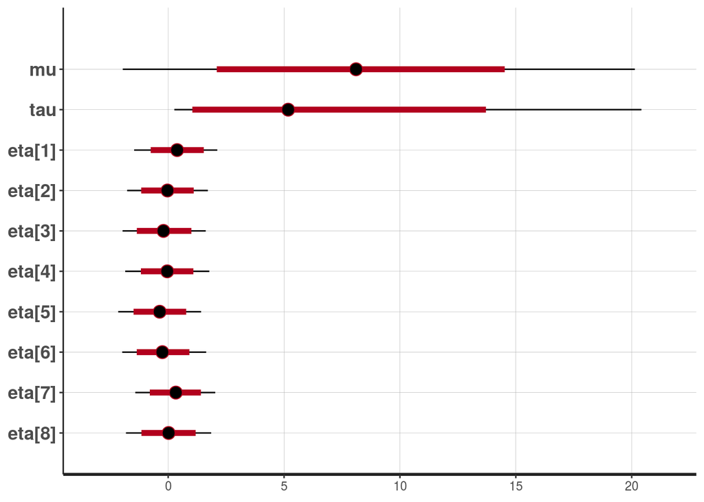

```r
plot(fit)
```

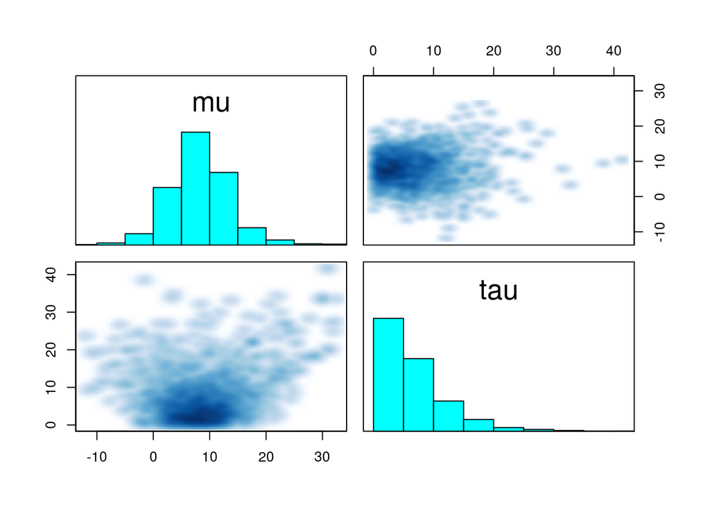

```r
pairs(fit, pars = c("mu", "tau"))
```